# Assignment 4 Solutions

```r
library(faraway)
```

**Problem 1.1**

```r
lgamble <- lm(gamble ~ sex + status + income + verbal, data=teengamb)
gm_sum <- summary(lgamble)
gm_sum
```

```
##
## Call:
## lm(formula = gamble ~ sex + status + income + verbal, data = teengamb)
##
## Residuals:
##     Min      1Q  Median      3Q     Max
## -51.082 -11.320  -1.451   9.452  94.252
##
## Coefficients:
##              Estimate Std. Error t value Pr(>|t|)
## (Intercept)  22.55565   17.19680   1.312   0.1968
## sex         -22.11833    8.21111  -2.694   0.0101 *
## status        0.05223    0.28111   0.186   0.8535
## income        4.96198    1.02539   4.839 1.79e-05 ***
## verbal       -2.95949    2.17215  -1.362   0.1803
## ---
## Signif. codes:  0 '***' 0.001 '**' 0.01 '*' 0.05 '.' 0.1 ' ' 1
##
## Residual standard error: 22.69 on 42 degrees of freedom
## Multiple R-squared:  0.5267, Adjusted R-squared:  0.4816
## F-statistic: 11.69 on 4 and 42 DF,  p-value: 1.815e-06
```

1. Note that the percentage of variation explained is equal to the “Multiple $R^2$” coefficient in the model summary. Thus, we find the percentage of variation explained is equal to approximately .5267.
2. We can find the largest residual as follows:

```r
gm_res <- gm_sum$residuals
max(gm_res)
```

```
## [1] 94.25222
```

With the value in mind, we use the “match” function to find the appropriate index:

```r
match(max(gm_res),gm_res)
```

```
## [1] 24
```

Thus the observation with the largest positive redsidual is number 24.

3. The median of the redsiduals is already computed by the model summary. We can also extract both the mean and median of the residuals as follows:

```r
summary(gm_res)
```

```
##    Min. 1st Qu.  Median    Mean 3rd Qu.    Max.
## -51.082 -11.320  -1.451   0.000   9.452  94.252
```

The mean is thus zero, and the median is -1.451.

4. We compute the correlation of the residuals with the fitted values as follows.

```r
cor(gm_res, lgamble$fitted.values)
```

```
## [1] -1.070659e-16
```

5. We compute the correlation of the residuals with income as follows:

```r
cor(gm_res, teengamb$income)
```

```
## [1] -7.242382e-17
```

6. Note, we will follow Faraway’s original intention in this example solution, but any justified interpretation of the problem is accepted.

In this case, as “sex” is a binary variable in the data with 0=male, 1=female, we say that for all other explanatory variables held equal, the difference in the response for the expected expenditure on gambling is the coefficient for $\boldsymbol{\beta}_{sex}=-22.11833$ found in the summary.

**Problem 1.2:**

We start by fitting the model for weekly wages as the response and years of education and experience as explanatory variables, i.e.,

```r
lwages <- lm(wage ~ educ + exper, data=uswages)
lwage_sum <- summary(lwages)
lwage_sum
```

```
##
## Call:
## lm(formula = wage ~ educ + exper, data = uswages)
##
## Residuals:
##     Min      1Q  Median      3Q     Max
## -1018.2  -237.9   -50.9   149.9  7228.6
##
## Coefficients:
##              Estimate Std. Error t value Pr(>|t|)
## (Intercept) -242.7994    50.6816  -4.791 1.78e-06 ***
## educ          51.1753     3.3419  15.313  < 2e-16 ***
## exper          9.7748     0.7506  13.023  < 2e-16 ***
## ---
## Signif. codes:  0 '***' 0.001 '**' 0.01 '*' 0.05 '.' 0.1 ' ' 1
##
## Residual standard error: 427.9 on 1997 degrees of freedom
## Multiple R-squared:  0.1351, Adjusted R-squared:  0.1343
## F-statistic:   156 on 2 and 1997 DF,  p-value: < 2.2e-16
```

According to this model fit, we say that the impact of education is much higher than the impact of experience in explaning the weeky wages.

Now we fit a similar model, but take the log of the response variable to fit our relationship. That is,

```r
log_wage_m <- lm(log(wage) ~ educ + exper, data=uswages)
log_wage_sum <- summary(log_wage_m)
log_wage_sum
```

```
##
## Call:
## lm(formula = log(wage) ~ educ + exper, data = uswages)
##
## Residuals:
##     Min      1Q  Median      3Q     Max
## -2.7533 -0.3495  0.1068  0.4381  3.5699
##
## Coefficients:
##             Estimate Std. Error t value Pr(>|t|)
## (Intercept) 4.650319   0.078354   59.35   <2e-16 ***
## educ        0.090506   0.005167   17.52   <2e-16 ***
## exper       0.018079   0.001160   15.58   <2e-16 ***
## ---
## Signif. codes:  0 '***' 0.001 '**' 0.01 '*' 0.05 '.' 0.1 ' ' 1
##
## Residual standard error: 0.6615 on 1997 degrees of freedom
## Multiple R-squared:  0.1749, Adjusted R-squared:  0.174
## F-statistic: 211.6 on 2 and 1997 DF,  p-value: < 2.2e-16
```

In this case, education has a stronger impact than experience on the logged weekly wages, similarly to the case with the linear scale for the weekly wages. However, we note that due to the log scale in the response variables, if we want to recover weekly wages from the relationship, we need to write the change in education $d_{x_1}$ as a change in the response approximately as
$$\begin{align}
\large{\approx e^{.09 d_{x_1}}}
\end{align}$$

This interpretation can be seen as more natural due to the differences in the standard error for the two models with the linear scale being much higher. As well, for zero years of experience and zero years of education, the linear scale will give negative weekly wages which is unphysical.

**Problem 1.3**

We will fit a model for “lpsa” as a response variable, and “lcavol” as the explanatory only variable, record $R^2$ and then introduce the explanatory variables “lweight”, “svi”, “lbph”, “age”, “lcp”, “pgg45” and “gleason” one at a time, recording these models’ $R^2$ values.

We note that we will create 8 different models, and create a vector for storage of the 8 residual standard error values and the 8 $R^2$ values:

```r
Rstd_err_storage <- c(0,0,0,0,0,0,0,0)
Rsqr_storage <- c(0,0,0,0,0,0,0,0)
```

Then we assemble the models and store the values

```r
tmp <- summary(lm(lpsa ~ lcavol, data = prostate))
Rstd_err_storage[1] <- tmp$sigma
Rsqr_storage[1] <- tmp$r.squared

tmp <- summary(lm(lpsa ~ lcavol + lweight, data = prostate))
Rstd_err_storage[2] <- tmp$sigma
Rsqr_storage[2] <- tmp$r.squared

tmp <- summary(lm(lpsa ~ lcavol + lweight + svi, data = prostate))
Rstd_err_storage[3] <- tmp$sigma
Rsqr_storage[3] <- tmp$r.squared

tmp <- summary(lm(lpsa ~ lcavol + lweight + svi + lbph, data = prostate))
Rstd_err_storage[4] <- tmp$sigma
Rsqr_storage[4] <- tmp$r.squared

tmp <- summary(lm(lpsa ~ lcavol + lweight + svi + lbph + age, data = prostate))
Rstd_err_storage[5] <- tmp$sigma
Rsqr_storage[5] <- tmp$r.squared

tmp <- summary(lm(lpsa ~ lcavol + lweight + svi + lbph + age + lcp, data = prostate))
Rstd_err_storage[6] <- tmp$sigma
Rsqr_storage[6] <- tmp$r.squared

tmp <- summary(lm(lpsa ~ lcavol + lweight + svi + lbph + age + lcp + pgg45, data = prostate))
Rstd_err_storage[7] <- tmp$sigma
Rsqr_storage[7] <- tmp$r.squared

tmp <- summary(lm(lpsa ~ lcavol + lweight + svi + lbph + age + lcp + pgg45 + gleason, data = prostate))
Rstd_err_storage[8] <- tmp$sigma
Rsqr_storage[8] <- tmp$r.squared
```

We load “ggplot2”

```r
library(ggplot2)
```

and create a dataframe for plotting

```r
plt_range <- c(1,2,3,4,5,6,7,8)
prost_analysis <- data.frame(plt_range, Rstd_err_storage, Rsqr_storage)
```

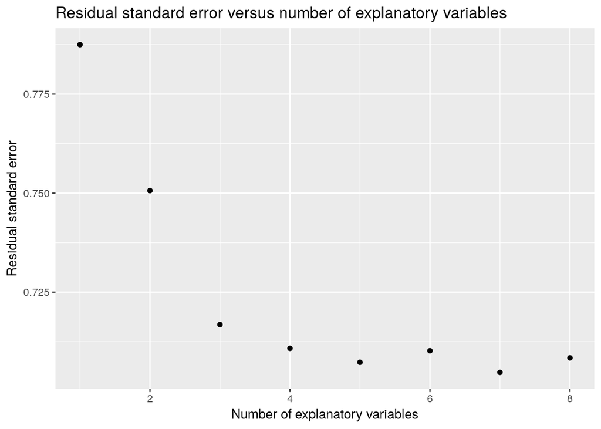

```r
ggplot(data=prost_analysis, aes(x=plt_range, y=Rstd_err_storage)) + geom_point() + labs(
   x = "Number of explanatory variables",
   y = "Residual standard error",
   title = "Residual standard error versus number of explanatory variables"
)
```

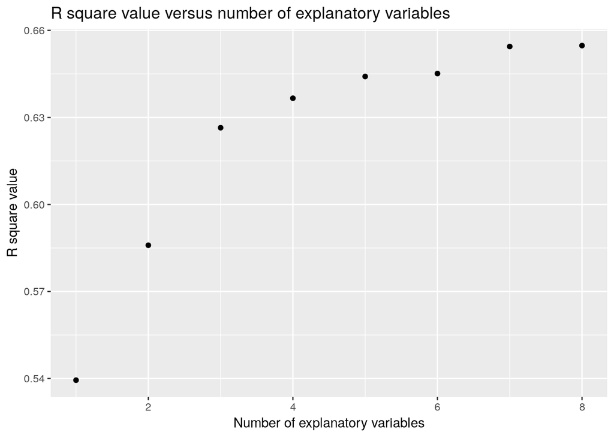

```r
ggplot(data=prost_analysis, aes(x=plt_range, y=Rsqr_storage)) + geom_point() + labs(
   x = "Number of explanatory variables",
   y = "R square value",
   title = "R square value versus number of explanatory variables"
)
```

**Problem 1.4**

This problem was more difficult than anticipated due to R plotting conventions – one solution is outlined in the following.

We will fit two models, “lpsa” versus “lcavol” and “lcavol” versus “lpsa” and store their summaries

```r
lm1 <- lm(lpsa ~ lcavol, data = prostate)
lm1_sum <- summary(lm1)
lm2 <- lm(lcavol ~ lpsa, data = prostate)
lm2_sum <- summary(lm2)
```

We note that in this case, the regression model is just the fit for a line in 2-D space. In particular, we find the two equations for the lines determined by the $\hat{\beta}$ values, i.e.,

```r
beta_lcavol <- lm1_sum$coefficients
beta_lcavol
```

```
##              Estimate Std. Error  t value     Pr(>|t|)
## (Intercept) 1.5072979 0.12193682 12.36130 1.722234e-21
## lcavol      0.7193201 0.06819288 10.54832 1.118616e-17
```

```r
beta_lpsa <- lm2_sum$coefficients
beta_lpsa
```

```
##               Estimate Std. Error  t value     Pr(>|t|)
## (Intercept) -0.5085802 0.19419311 -2.61894 1.026687e-02
## lpsa         0.7499191 0.07109372 10.54832 1.118616e-17
```

Let us denote “lpsa” the variable $x_1$ and let us denote “lcavol” the variable $x_2$. Then we consider $\beta\_lcavol$ as defined above defines the line,
$$\begin{align}
x_1 = (\beta\_lcavol)_0 + (\beta\_lcavol)_1 x_2
\end{align}$$
while $\beta\_lpsa$ will define the line
$$\begin{align}
x_2 = (\beta\_lpsa)_0 + (\beta\_lpsa)_1 x_1
\end{align}$$

In R, we can plot these lines together with the “plot” function and the “lines” function most easily. This is done as follows, setting: * first, the plot of the data; * second, the predicted values for the first linear model in the y-axis versus the recorded values for lcavol in the x-axis; * third, the recorderd values for LPSA in the y-axis versus the predicted values under the second model for lcavol in the x-axis.

Additionally, we add titles and labels in the plot function as keyword arguments.

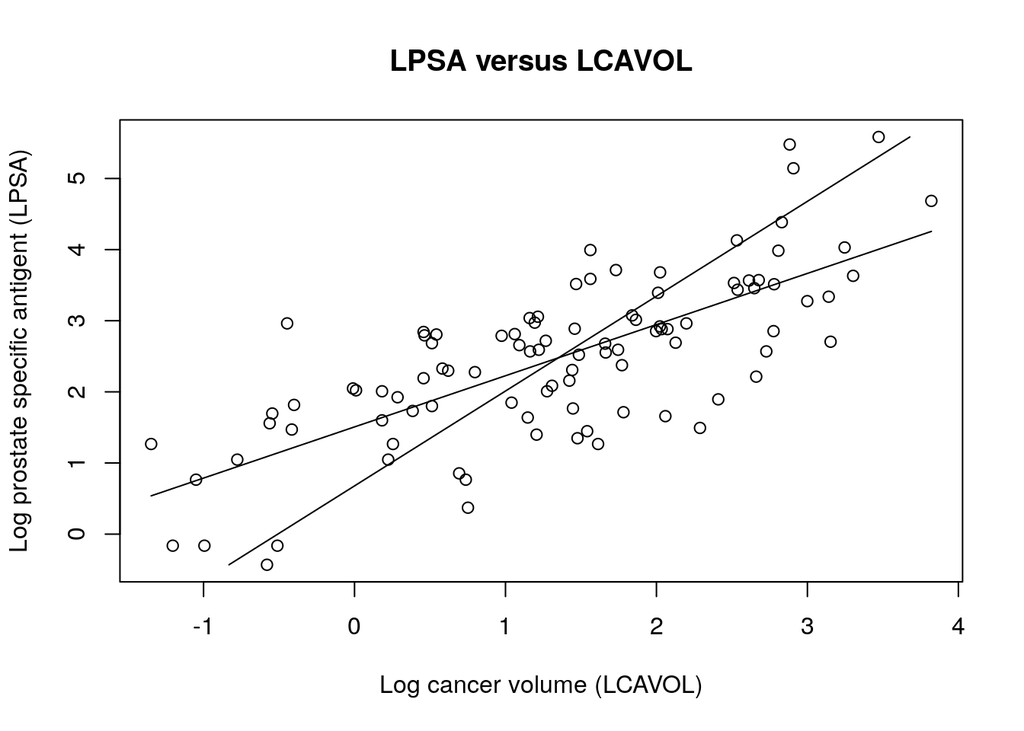

```r
plot(prostate$lcavol, prostate$lpsa, xlab="Log cancer volume (LCAVOL)",
     ylab="Log prostate specific antigent (LPSA)", main="LPSA versus LCAVOL")
lines(prostate$lcavol, lm1$fitted.values)
lines(lm2$fitted.values, prostate$lpsa)
```

By inspection, we say these two predictions intersect around the coordinate (1.2, 2.5).

**Problem 1.5**

We will fit the linear model from the data “wafer” as follows

```r
wafer_lm <- lm(resist ~ x1 + x2 + x3 + x4, data=wafer)
```

1. We will inspect how the values have been encoded in the model, particularly,

```r
head(wafer)
```

|  | x1 | x2 | x3 | x4 | resist |
| --- | --- | --- | --- | --- | --- |
| 1 | - | - | - | - | 193.4 |
| 2 | + | - | - | - | 247.6 |
| 3 | - | + | - | - | 168.2 |
| 4 | + | + | - | - | 205.0 |
| 5 | - | - | + | - | 303.4 |
| 6 | + | - | + | - | 339.9 |

and

```r
X_mat <- model.matrix(wafer_lm)
X_mat
```

```
##    (Intercept) x1+ x2+ x3+ x4+
## 1            1   0   0   0   0
## 2            1   1   0   0   0
## 3            1   0   1   0   0
## 4            1   1   1   0   0
## 5            1   0   0   1   0
## 6            1   1   0   1   0
## 7            1   0   1   1   0
## 8            1   1   1   1   0
## 9            1   0   0   0   1
## 10           1   1   0   0   1
## 11           1   0   1   0   1
## 12           1   1   1   0   1
## 13           1   0   0   1   1
## 14           1   1   0   1   1
## 15           1   0   1   1   1
## 16           1   1   1   1   1
## attr(,"assign")
## [1] 0 1 2 3 4
## attr(,"contrasts")
## attr(,"contrasts")$x1
## [1] "contr.treatment"
##
## attr(,"contrasts")$x2
## [1] "contr.treatment"
##
## attr(,"contrasts")$x3
## [1] "contr.treatment"
##
## attr(,"contrasts")$x4
## [1] "contr.treatment"
```

Zero corresponds to “-” and one corresponds to “+”.

2. We compute the correlation of the $X$ matrix as follows:

```r
cor(X_mat)
```

```
##             (Intercept) x1+ x2+ x3+ x4+
## (Intercept)           1  NA  NA  NA  NA
## x1+                  NA   1   0   0   0
## x2+                  NA   0   1   0   0
## x3+                  NA   0   0   1   0
## x4+                  NA   0   0   0   1
```

We notice that the correlation of the intercept with the explanatory variables is not available; we should understand this because the mean of the intercept term is just equal to 1. Therefore, the anomalies of the intercept will be given by the vector of zeros. If there is zero variance of this term, we cannot compute the correlations.

3. Moving to the high level of $x_1$ from the low level acts as a switch, where the value $\hat{\boldsymbol{\beta}}_1$ is included in the response. In particular, we find

```r
summary(wafer_lm)
```

```
##
## Call:
## lm(formula = resist ~ x1 + x2 + x3 + x4, data = wafer)
##
## Residuals:
##     Min      1Q  Median      3Q     Max
## -43.381 -17.119   4.825  16.644  33.769
##
## Coefficients:
##             Estimate Std. Error t value Pr(>|t|)
## (Intercept)   236.78      14.77  16.032 5.65e-09 ***
## x1+            25.76      13.21   1.950 0.077085 .
## x2+           -69.89      13.21  -5.291 0.000256 ***
## x3+            43.59      13.21   3.300 0.007083 **
## x4+           -14.49      13.21  -1.097 0.296193
## ---
## Signif. codes:  0 '***' 0.001 '**' 0.01 '*' 0.05 '.' 0.1 ' ' 1
##
## Residual standard error: 26.42 on 11 degrees of freedom
## Multiple R-squared:  0.7996, Adjusted R-squared:  0.7267
## F-statistic: 10.97 on 4 and 11 DF,  p-value: 0.0007815
```

the response changes by 25.76.

4. We now re-fit the model without $x_4$ and we find the following summary,

```r
wafer_lm_new <-  lm(resist ~ x1 + x2 + x3, data=wafer)
summary(wafer_lm_new)
```

```
##
## Call:
## lm(formula = resist ~ x1 + x2 + x3, data = wafer)
##
## Residuals:
##     Min      1Q  Median      3Q     Max
## -36.137 -20.550   3.575  18.462  41.013
##
## Coefficients:
##             Estimate Std. Error t value Pr(>|t|)
## (Intercept)   229.54      13.32  17.231 7.88e-10 ***
## x1+            25.76      13.32   1.934 0.077047 .
## x2+           -69.89      13.32  -5.246 0.000206 ***
## x3+            43.59      13.32   3.272 0.006677 **
## ---
## Signif. codes:  0 '***' 0.001 '**' 0.01 '*' 0.05 '.' 0.1 ' ' 1
##
## Residual standard error: 26.64 on 12 degrees of freedom
## Multiple R-squared:  0.7777, Adjusted R-squared:  0.7221
## F-statistic: 13.99 on 3 and 12 DF,  p-value: 0.0003187
```

We notice that the values for the remaining parameters $\hat{\boldsymbol{\beta}}_i$ don’t change for $i=1,2,3$, but the standard errors and the intercept term slightly change.

5. The above preservation of the $\hat{\boldsymbol{\beta}}_i$ is expected as the correlation (or covariance) between the explanatory variables is zero.